# SoS Workflow Report

| Command Line | `sos run Outcome_Oriented_Step_Targets.sos -p Outcome_Target_Report.html -d` |
| --- | --- |
| Project directory | `/home/gaow/Documents/GIT/wiki/sos-docs/src/examples` |
| Worklow Name | `default` |
| Worklow ID | `b5413c8033e193b5` |
| Worklow Start Time | 2018-06-13 20:19:02 (1528939142.3486753) |
| Worklow End Time | 2018-06-13 20:19:34 |
| Worklow Duration | 32 sec |
| Completed steps | 8 |
| Completed substeps | 28 |

## Steps

Workflow

Step

Input

Output

Start Time

Duration

Timeline

Steps

Substeps

Tasks

default

2018-06-13 20:19:02

32 sec

8 completed

28 completed

simulation

data_1.train.csv (10)

- data_1.train.csv 6.5 kB
- data_1.test.csv 32.6 kB
- data_2.train.csv 6.5 kB
- data_2.test.csv 32.5 kB
- data_3.train.csv 6.5 kB
- data_3.test.csv 32.6 kB
- data_4.train.csv 6.6 kB
- data_4.test.csv 32.6 kB
- data_5.train.csv 6.5 kB
- data_5.test.csv 32.6 kB

2018-06-13 20:19:09

3 sec

1 completed

5 completed

lasso

data_1.train.csv (10)

- data_1.train.csv 6.5 kB
- data_1.test.csv 32.6 kB
- data_2.train.csv 6.5 kB
- data_2.test.csv 32.5 kB
- data_3.train.csv 6.5 kB
- data_3.test.csv 32.6 kB
- data_4.train.csv 6.6 kB
- data_4.test.csv 32.6 kB
- data_5.train.csv 6.5 kB
- data_5.test.csv 32.6 kB

data_1.lasso.pred... (10)

- data_1.lasso.predicted.csv 5.1 kB
- data_1.lasso.coef.csv 204 Bytes
- data_2.lasso.predicted.csv 5.1 kB
- data_2.lasso.coef.csv 200 Bytes
- data_3.lasso.predicted.csv 5.1 kB
- data_3.lasso.coef.csv 203 Bytes
- data_4.lasso.predicted.csv 5.1 kB
- data_4.lasso.coef.csv 200 Bytes
- data_5.lasso.predicted.csv 5.1 kB
- data_5.lasso.coef.csv 203 Bytes

2018-06-13 20:19:12

6 sec

1 completed

5 completed

evaluation_lasso

data_1.lasso.mse.csv (5)

- data_1.lasso.mse.csv 28 Bytes
- data_2.lasso.mse.csv 28 Bytes
- data_3.lasso.mse.csv 28 Bytes
- data_4.lasso.mse.csv 27 Bytes
- data_5.lasso.mse.csv 28 Bytes

2018-06-13 20:19:18

6 sec

1 completed

1 completed

ridge

data_1.train.csv (10)

- data_1.train.csv 6.5 kB
- data_1.test.csv 32.6 kB
- data_2.train.csv 6.5 kB
- data_2.test.csv 32.5 kB
- data_3.train.csv 6.5 kB
- data_3.test.csv 32.6 kB
- data_4.train.csv 6.6 kB
- data_4.test.csv 32.6 kB
- data_5.train.csv 6.5 kB
- data_5.test.csv 32.6 kB

data_1.ridge.pred... (10)

- data_1.ridge.predicted.csv 3.5 kB
- data_1.ridge.coef.csv 143 Bytes
- data_2.ridge.predicted.csv 3.5 kB
- data_2.ridge.coef.csv 144 Bytes
- data_3.ridge.predicted.csv 3.5 kB
- data_3.ridge.coef.csv 142 Bytes
- data_4.ridge.predicted.csv 3.5 kB
- data_4.ridge.coef.csv 144 Bytes
- data_5.ridge.predicted.csv 3.5 kB
- data_5.ridge.coef.csv 145 Bytes

2018-06-13 20:19:12

19 sec

1 completed

5 completed

evaluation_ridge

data_1.ridge.mse.csv (5)

- data_1.ridge.mse.csv 33 Bytes
- data_2.ridge.mse.csv 34 Bytes
- data_3.ridge.mse.csv 34 Bytes
- data_4.ridge.mse.csv 35 Bytes
- data_5.ridge.mse.csv 34 Bytes

2018-06-13 20:19:31

2 sec

1 completed

1 completed

default

data_1.lasso.mse.csv (10)

- data_1.lasso.mse.csv 28 Bytes
- data_2.lasso.mse.csv 28 Bytes
- data_3.lasso.mse.csv 28 Bytes
- data_4.lasso.mse.csv 27 Bytes
- data_5.lasso.mse.csv 28 Bytes
- data_1.ridge.mse.csv 33 Bytes
- data_2.ridge.mse.csv 34 Bytes
- data_3.ridge.mse.csv 34 Bytes
- data_4.ridge.mse.csv 35 Bytes
- data_5.ridge.mse.csv 34 Bytes

2018-06-13 20:19:34

0 sec

1 completed

1 completed

evaluation_core

2018-06-13 20:19:18

6 sec

1 completed

5 completed

evaluation_core

data_1.test.csv (15)

- data_1.test.csv 32.6 kB
- data_1.lasso.predicted.csv 5.1 kB
- data_1.lasso.coef.csv 204 Bytes
- data_2.test.csv 32.5 kB
- data_2.lasso.predicted.csv 5.1 kB
- data_2.lasso.coef.csv 200 Bytes
- data_3.test.csv 32.6 kB
- data_3.lasso.predicted.csv 5.1 kB
- data_3.lasso.coef.csv 203 Bytes
- data_4.test.csv 32.6 kB
- data_4.lasso.predicted.csv 5.1 kB
- data_4.lasso.coef.csv 200 Bytes
- data_5.test.csv 32.6 kB
- data_5.lasso.predicted.csv 5.1 kB
- data_5.lasso.coef.csv 203 Bytes

data_1.lasso.mse.csv (5)

- data_1.lasso.mse.csv 28 Bytes
- data_2.lasso.mse.csv 28 Bytes
- data_3.lasso.mse.csv 28 Bytes
- data_4.lasso.mse.csv 27 Bytes
- data_5.lasso.mse.csv 28 Bytes

2018-06-13 20:19:18

6 sec

1 completed

5 completed

evaluation_core

2018-06-13 20:19:31

2 sec

1 completed

5 completed

evaluation_core

data_1.test.csv (15)

- data_1.test.csv 32.6 kB
- data_1.ridge.predicted.csv 3.5 kB
- data_1.ridge.coef.csv 143 Bytes
- data_2.test.csv 32.5 kB
- data_2.ridge.predicted.csv 3.5 kB
- data_2.ridge.coef.csv 144 Bytes
- data_3.test.csv 32.6 kB
- data_3.ridge.predicted.csv 3.5 kB
- data_3.ridge.coef.csv 142 Bytes
- data_4.test.csv 32.6 kB
- data_4.ridge.predicted.csv 3.5 kB
- data_4.ridge.coef.csv 144 Bytes
- data_5.test.csv 32.6 kB
- data_5.ridge.predicted.csv 3.5 kB
- data_5.ridge.coef.csv 145 Bytes

data_1.ridge.mse.csv (5)

- data_1.ridge.mse.csv 33 Bytes
- data_2.ridge.mse.csv 34 Bytes
- data_3.ridge.mse.csv 34 Bytes
- data_4.ridge.mse.csv 35 Bytes
- data_5.ridge.mse.csv 34 Bytes

1 sec

1 completed

5 completed

## Execution DAG

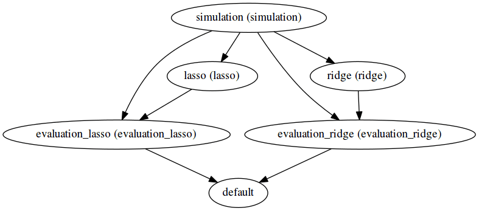

## Script

102 lines 4.5 kB